# Lección 1

por Manuel Villalobos

9/10/2017

## Introducción a R

En esta parte quiero mostrarles que es R para aquellos que no han tenido un acercamiento a esta herramienta. R es un programa libre para hacer estadística mucho más poderosa que Excel. La gran ventaja de R es que es completamente gratuito y cualquier usuario puede desarrollar herramientas y posteriormente liberarlas. Es por esta razón que R se ha convertido en una manera sencilla de compartir código para análisis de datos masivos.

Además, en este curso usaremos R con un ambiente grafico llamado RStudio, que nos permite visualizar tanto el campo de trabajo como las salidas de nuestros diferentes análisis.

Tu puedes escribir en la parte de código en RStudio las siguientes instrucciones y al dar enter, estas se ejecutarán y se verán la parte inferior de tu pantalla. En estos ejercicios tu veras dos recuadros, uno con las instrucciones a ejecutar y otro el resultado anteponiéndose el símbolo [1].

### Copia y pega en R las instrucciones y ve si las puedes ejecutar

```r
#para ubicarte en una dirección dentro de tu sistema puedes usar:

setwd("~/Desktop/Curso_queretaro2017")

#Para imprimir un texto en pantalla usamos la siguiente instrucción.

print("Nosotros estamos aprendiendo a trabajar en R")    #copien y peguen esta instrucción en R y vean que sucede.
```

```
## [1] "Nosotros estamos aprendiendo a trabajar en R"
```

```r
#Para saber qué hace y cómo opera una función en R, puedes obtener ayuda usando la siguiente sintaxis.

?print

#La ayuda en RStudio aparecerá en la parte izquierda de tu pantalla.

#Para salir del programa que estamos haciendo en R usamos la siguiente instrucción:

#quit()

#R preguntara si deseas guardar tu trabajo y puedes o no hacerlo dependiendo de lo que desees.
```

## Usando a R como calculadora y declarando variables:

```r
#Aquí haremos operaciones matemáticas básicas.

4+6
```

```
## [1] 10
```

```r
5-3
```

```
## [1] 2
```

```r
30/6
```

```
## [1] 5
```

```r
8 * sqrt (4)
```

```
## [1] 16
```

```r
#Prueben ahora las que ustedes deseen.

#R nos da la capacidad de declarar variables y guardar en ellas valores o resultados de los procesos ejecutados previamente.

x = 3 + 5

impacto=21

#Para ver lo que contiene la variable en pantalla, simplemente escribimos la variable y damos enter:

impacto
```

```
## [1] 21
```

```r
#Esto nos ayuda a mantener estas variables y llamarlas en cualquier otra operación posterior.

impacto * x
```

```
## [1] 168
```

```r
#En R podemos crear objetos que contengan varios valores, estos son llamados vectores y se declaran usando la función c().

impactos= c(10, 40, 12, 3, 5, 21, 8)

#Escriban la variable para visualizar los valores que contiene

impactos
```

```
## [1] 10 40 12  3  5 21  8
```

```r
#podemos hacer diferentes operaciones con este objeto y estas afectarán a todos los valores contenidos en él.

impactos + 1
```

```
## [1] 11 41 13  4  6 22  9
```

```r
impactos * 2
```

```
## [1] 20 80 24  6 10 42 16
```

```r
impactos / 2
```

```
## [1]  5.0 20.0  6.0  1.5  2.5 10.5  4.0
```

```r
#Pueden probar cosas como:

impactos2= impactos * 2

impactos * impactos2
```

```
## [1]  200 3200  288   18   50  882  128
```

```r
#Existen en R muchas funciones interesantes para realizar análisis estadísticos sobre datos masivos, tales como encontrar el promedio de los datos, el valor máximo o mínimo, etc.


mean(impactos)
```

```
## [1] 14.14286
```

```r
sum(impactos)
```

```
## [1] 99
```

```r
max(impactos)
```

```
## [1] 40
```

```r
min(impactos)
```

```
## [1] 3
```

```r
range(impactos)
```

```
## [1]  3 40
```

```r
sort(impactos)
```

```
## [1]  3  5  8 10 12 21 40
```

```r
unique(impactos)
```

```
## [1] 10 40 12  3  5 21  8
```

## Ejercicio

### ¿Qué hace la función “range”?

## Tipos de objetos

#### En R, al igual que en otros lenguajes de programación, podemos no solo guardar objetos que contengan valores numéricos, si no también cadenas que contengan texto:

```r
revistas = c ("PNAS", "Nature", "PBiology", "Pone", "Pgenetics", "NatureP", "Development")


#Ahora podemos etiquetar los valores del anterior vector, usando el nuevo

names(impactos) = revistas


#ahora visualicen impactos!! ¿Qué ven?


#En ocasiones no queremos aplicar las operaciones a todos los valores contenidos en un vector y en R podemos especificar qué posición del vector queremos alterar.


impactos[1]
```

```
## PNAS
##   10
```

```r
##¿para visualizar el tercer elemento?


#Pero dado que nuestro vector "impactos"" ya tiene nombres, podemos también hacer uso de estos:

impactos["Nature"]
```

```
## Nature
##     40
```

```r
#también puedes pedir varios elementos del objeto:

impactos[c(1,5)]
```

```
##      PNAS Pgenetics
##        10         5
```

```r
#podemos eliminar elementos del vector:

impactos[-c(1,5)]
```

```
##      Nature    PBiology        Pone     NatureP Development
##          40          12           3          21           8
```

## Ejercicio

### ¿Cuál es la revista que tiene menor impacto?

### ¿Pueden crear un nuevo vector que ya no contenga a Nature y hacer otro vector nuevo y saber además cuál es el promedio de impactos, sin esta revista?

## Operaciones racionales

#### Al hacer comparaciones entre datos, necesitamos usar funciones que nos digan, por ejemplo, si cierto gen pasa un número de lecturas o no. Para este tipo de preguntas usamos las siguientes funciones:

```r
impactos > 21
```

```
##        PNAS      Nature    PBiology        Pone   Pgenetics     NatureP
##       FALSE        TRUE       FALSE       FALSE       FALSE       FALSE
## Development
##       FALSE
```

```r
#podemos preguntar cuáles son menores, mayores o iguales a cierto valor

impactos < 21
```

```
##        PNAS      Nature    PBiology        Pone   Pgenetics     NatureP
##        TRUE       FALSE        TRUE        TRUE        TRUE       FALSE
## Development
##        TRUE
```

```r
impactos <=21
```

```
##        PNAS      Nature    PBiology        Pone   Pgenetics     NatureP
##        TRUE       FALSE        TRUE        TRUE        TRUE        TRUE
## Development
##        TRUE
```

```r
impactos == 21
```

```
##        PNAS      Nature    PBiology        Pone   Pgenetics     NatureP
##       FALSE       FALSE       FALSE       FALSE       FALSE        TRUE
## Development
##       FALSE
```

```r
#En todos los casos R nos da un vector de FALSE/TRUE (valores lógicos) y son útiles para muchos casos, en donde queremos saber cosas de los objetos que cumplen cierta condición:

#¿Cuantas revistas tienen más de 10 de impacto?

sum(impactos > 10)
```

```
## [1] 3
```

## Ejercicio

### ¿cómo podemos ver las revistas que tienen un impacto mayor al promedio de todas?

## Generación de sucesiones

```r
#En R existen varias funciones para generar sucesiones numéricas. Por ejemplo:
1:30
```

```
##  [1]  1  2  3  4  5  6  7  8  9 10 11 12 13 14 15 16 17 18 19 20 21 22 23
## [24] 24 25 26 27 28 29 30
```

```r
#El operador ’dos puntos’ tiene máxima prioridad en una expresión, así, por ejemplo:

2*1:15
```

```
##  [1]  2  4  6  8 10 12 14 16 18 20 22 24 26 28 30
```

```r
#La función seq() permite generar sucesiones más complejas.

seq(-5, 5, by=.2)
```

```
##  [1] -5.0 -4.8 -4.6 -4.4 -4.2 -4.0 -3.8 -3.6 -3.4 -3.2 -3.0 -2.8 -2.6 -2.4
## [15] -2.2 -2.0 -1.8 -1.6 -1.4 -1.2 -1.0 -0.8 -0.6 -0.4 -0.2  0.0  0.2  0.4
## [29]  0.6  0.8  1.0  1.2  1.4  1.6  1.8  2.0  2.2  2.4  2.6  2.8  3.0  3.2
## [43]  3.4  3.6  3.8  4.0  4.2  4.4  4.6  4.8  5.0
```

## Haciendo gráficas en R

### Esta parte es la mejor de R, podemos generar una gran cantidad de gráficos que expresen de una manera interesante nuestros datos:

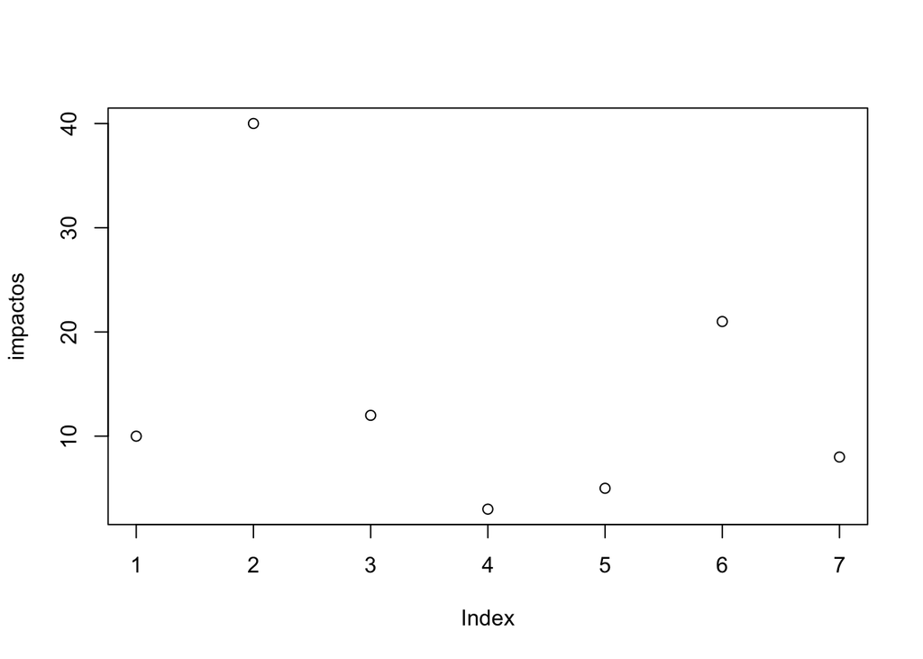

```r
plot(impactos)
```

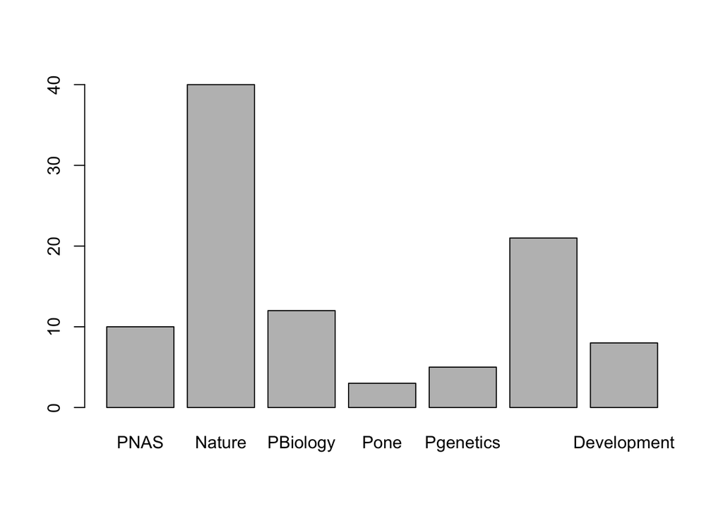

```r
barplot(impactos)
```

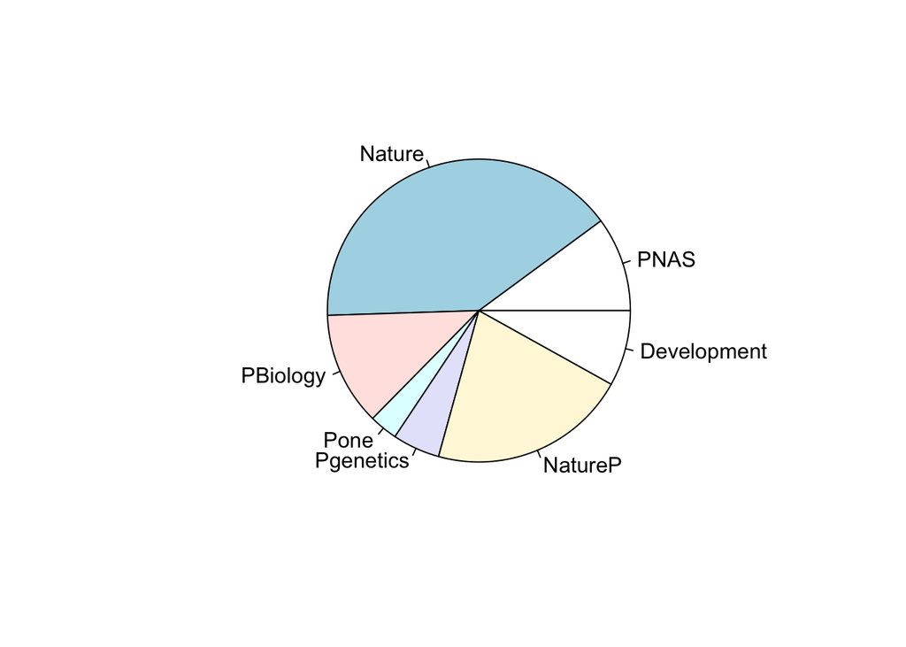

```r
pie(impactos)
```

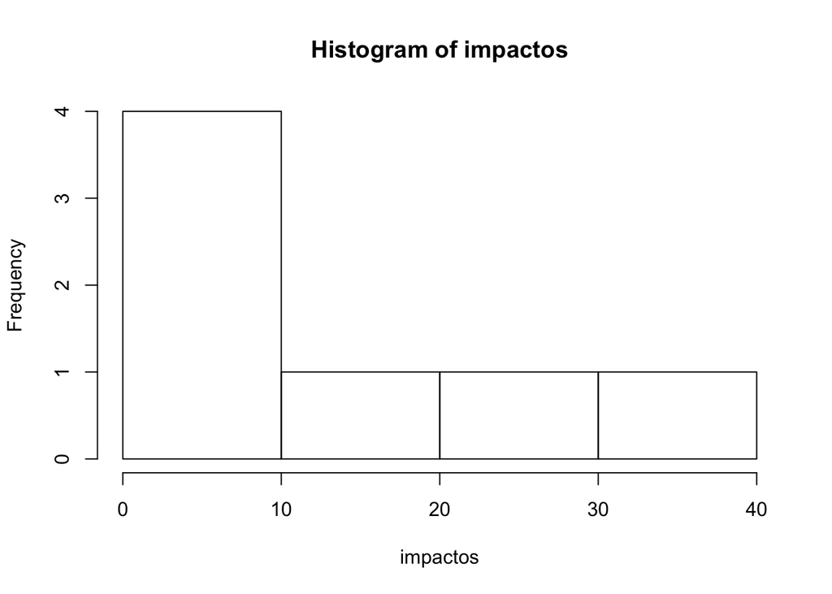

```r
hist(impactos)
```

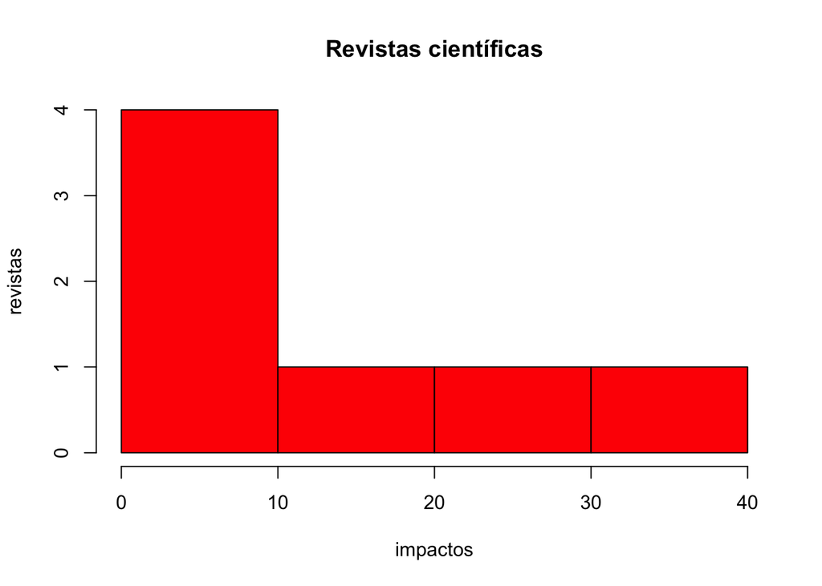

```r
#Usando las instrucciones en la opción de ayuda para cada gráfico y herramientas en la web, podemos construir gráficos cada vez más sofisticados:

hist(impactos, col= "red", main = "Revistas científicas", ylab= "revistas")
```

```r
#esta imagen la podemos guardar directamente desde RStudio o dar una instrucción:

pdf("histograma_revistas.pdf")

hist(impactos, col= "red", main = "Revistas científicas", ylab= "revistas")

dev.off()
```

```r
#llamamos a nuestra tabla que existe en nuestra carpeta del curso:

tab = read.table("tabla.txt")

tab
```

```
##        cond1 cond2 cond3
## gene1    252   233   182
## gene2    141   179   216
## gene3    165   195   175
## gene4    174   190   188
## gene5    192   231   194
## gene6    225   142   197
## gene7    176   190   218
## gene8    191   210   175
## gene9    229   162   191
## gene10   170   112   192
## gene11   125   194   215
## gene12   229   179   188
## gene13   176   267   201
## gene14   190   201   199
## gene15   189   295   171
## gene16   239   222   192
## gene17   170   202   228
## gene18   233   288   231
## gene19   180   276   201
## gene20   219   180   185
## gene21   229   185   198
## gene22   223   186   191
## gene23   203   224   188
## gene24   161   173   174
## gene25   247   144   210
## gene26   199   241   170
## gene27   224    56   208
## gene28   260   147   208
## gene29   225   217   165
## gene30   327   243   184
## gene31   171   250   195
## gene32   244   241   186
## gene33   170   121   195
## gene34   115   166   219
## gene35   272   240   206
## gene36   131   210   210
## gene37   240   206   242
## gene38   173   230   170
## gene39   279   257   187
## gene40    85   243   215
## gene41   175   167   159
## gene42   231   163   217
## gene43   198   273   236
## gene44   214   195   250
## gene45   219   208   170
## gene46   235   157   199
## gene47   171   266   210
## gene48   315   195   171
## gene49   215   198   229
## gene50   206   210   191
```

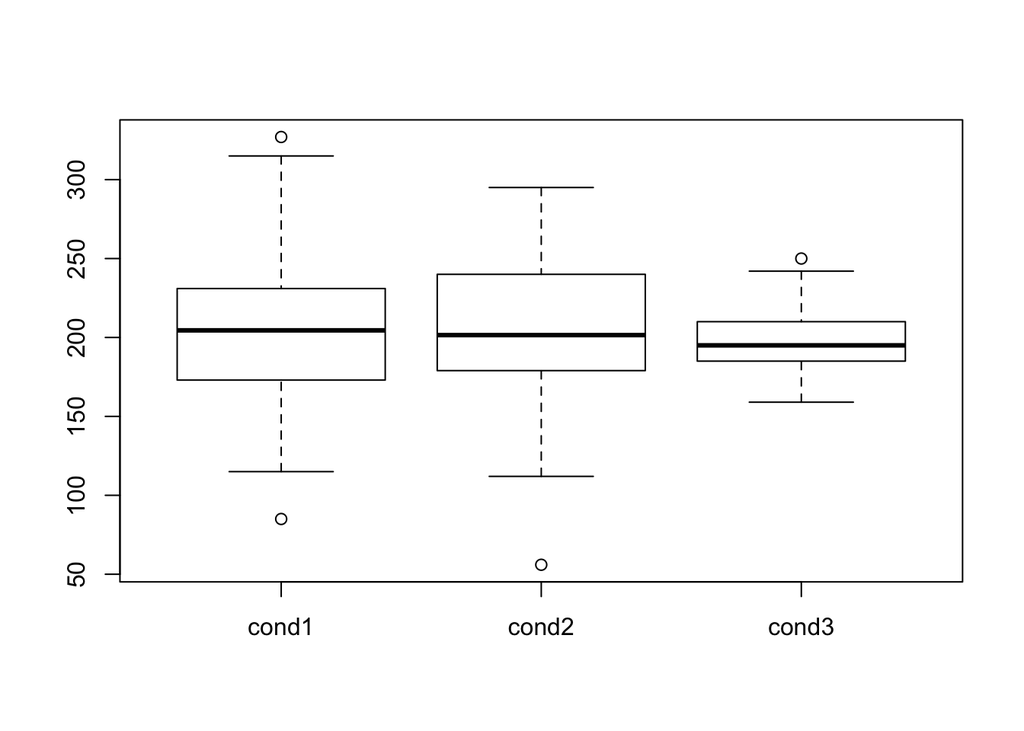

```r
#Ahora podemos visualizar estos datos usando la función boxplo():

boxplot(tab)
```

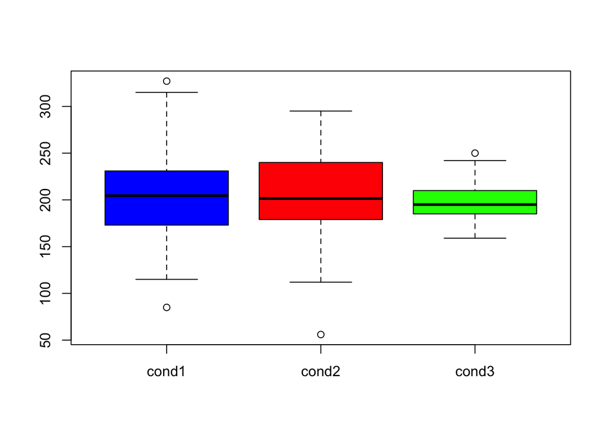

```r
#Lo podemos visualizar más bonito:

boxplot(tab, col=c("blue", "red", "green"))
```

```r
#Ahora como vimos antes, podemos extraer de esta tabla los valores que queramos, por ejemplo:


tab[c(1,6,10), c(1,3)]
```

```
##        cond1 cond3
## gene1    252   182
## gene6    225   197
## gene10   170   192
```

```r
#Y también podemos seleccionar los valores ya sea por columnas o por filas:


tab[c(1,6,10 ), ]
```

```
##        cond1 cond2 cond3
## gene1    252   233   182
## gene6    225   142   197
## gene10   170   112   192
```

```r
tab[, c(1,3)]
```

```
##        cond1 cond3
## gene1    252   182
## gene2    141   216
## gene3    165   175
## gene4    174   188
## gene5    192   194
## gene6    225   197
## gene7    176   218
## gene8    191   175
## gene9    229   191
## gene10   170   192
## gene11   125   215
## gene12   229   188
## gene13   176   201
## gene14   190   199
## gene15   189   171
## gene16   239   192
## gene17   170   228
## gene18   233   231
## gene19   180   201
## gene20   219   185
## gene21   229   198
## gene22   223   191
## gene23   203   188
## gene24   161   174
## gene25   247   210
## gene26   199   170
## gene27   224   208
## gene28   260   208
## gene29   225   165
## gene30   327   184
## gene31   171   195
## gene32   244   186
## gene33   170   195
## gene34   115   219
## gene35   272   206
## gene36   131   210
## gene37   240   242
## gene38   173   170
## gene39   279   187
## gene40    85   215
## gene41   175   159
## gene42   231   217
## gene43   198   236
## gene44   214   250
## gene45   219   170
## gene46   235   199
## gene47   171   210
## gene48   315   171
## gene49   215   229
## gene50   206   191
```

```r
#y podemos utilizar nuestras funciones para sucesiones:

tab[c(1:20), ]
```

```
##        cond1 cond2 cond3
## gene1    252   233   182
## gene2    141   179   216
## gene3    165   195   175
## gene4    174   190   188
## gene5    192   231   194
## gene6    225   142   197
## gene7    176   190   218
## gene8    191   210   175
## gene9    229   162   191
## gene10   170   112   192
## gene11   125   194   215
## gene12   229   179   188
## gene13   176   267   201
## gene14   190   201   199
## gene15   189   295   171
## gene16   239   222   192
## gene17   170   202   228
## gene18   233   288   231
## gene19   180   276   201
## gene20   219   180   185
```